# Simulations and Modeling Strategy

Matthew Peverill

2024-01-29

This document describes a series of simulations performed in order to develop a model testing our second hypothesis (that bias would become more severe as QC became more stringent). We are simulating missingness of sex as the underlying distribution is known. We simulate participant missingness under a number of conditions. To improve the verisimilitude of the simulations, we aimed approximately for the missingness levels we see in our data at no scrubbing and each of the five motion scrubbing thresholds:

- 0.191647019
- 0.215223981
- 0.22010778
- 0.233917144
- 0.283681374
- 0.557931964

# Simulation

```r
library(tidyverse)
library(lme4)
library(rsq)
library(emmeans)
library(lattice)
library(lmerTest)
set.seed(101)
emm_options(pbkrtest.limit = 72000)

base <- data.frame(
  sid = 1:12000,
  miss.0 = rep(FALSE, 12000),
  miss.1 = rep(FALSE, 12000),
  miss.2 = rep(FALSE, 12000),
  miss.3 = rep(FALSE, 12000),
  miss.4 = rep(FALSE, 12000),
  miss.5 = rep(FALSE, 12000),
  sex = as.factor(rbinom(12000, 1, .5))
)

# In the null simulation, each step has a bit more missing regardless of sex.
# The exact number are based on what we see in the data.
nulsim <- base
nulsim$miss.0[1:2276] <- TRUE
nulsim$miss.1[1:2556] <- TRUE
nulsim$miss.2[1:2614] <- TRUE
nulsim$miss.3[1:2778] <- TRUE
nulsim$miss.4[1:3369] <- TRUE
nulsim$miss.5[1:6626] <- TRUE
nulsim <- # shuffle pt order to avoid optimizer problems.
  nulsim %>% slice_sample(prop = 1) %>% mutate(sid = as.factor(sid))
nulsim.l <-
  nulsim %>% pivot_longer(c(-sex, -sid), names_to = "stringency", values_to =
                            "ismiss")
nulsim.l$pmiss <- rep(nulsim.l %>%
                        group_by(stringency) %>%
                        summarise(cnt = sum(ismiss) / 12000) %>%
                        pull(cnt),
                      12000)


replace_true_conditional <- function(vec, vec2, p1, p2) {
  zero_indices <- which(vec2 == 0)
  one_indices <- which(vec2 == 1)
  # Replace zero indices up to p1*total length with TRUE
  vec[zero_indices[1:(p1 * length(zero_indices))]] <- TRUE
  # Replace one indices up to p2*total length with TRUE
  vec[one_indices[1:(p2 * length(one_indices))]] <- TRUE
  return(vec)
}

# H1 simulation: each step has 12% more missing males and 8% more missing
# females (i.e. there is a bias but it is of the same size as stringency
# increases.)
h1sim <- base
h1sim$miss.1 <-
  replace_true_conditional(h1sim$miss.0, h1sim$sex, .08, .12)
h1sim$miss.2 <-
  replace_true_conditional(h1sim$miss.0, h1sim$sex, .16, .24)
h1sim$miss.3 <-
  replace_true_conditional(h1sim$miss.0, h1sim$sex, .24, .36)
h1sim$miss.4 <-
  replace_true_conditional(h1sim$miss.0, h1sim$sex, .36, .48)
h1sim$miss.5 <-
  replace_true_conditional(h1sim$miss.0, h1sim$sex, .42, .62)
h1sim <-
  h1sim %>% slice_sample(prop = 1) %>% mutate(sid = as.factor(sid))
h1sim.l <-
  h1sim %>% pivot_longer(c(-sex, -sid), names_to = "stringency", values_to =
                           "ismiss")
h1sim.l$pmiss <- rep(h1sim.l %>%
                       group_by(stringency) %>%
                       summarise(cnt = sum(ismiss) / 12000) %>%
                       pull(cnt),
                     12000)

# H2 simulation: Missingness starts out equal, but gets more severe at each step.
h2sim <- base
h2sim$miss.1 <-
  replace_true_conditional(h2sim$miss.0, h2sim$sex, .8, .12)  #4
h2sim$miss.2 <-
  replace_true_conditional(h2sim$miss.0, h2sim$sex, .16, .26) #10
h2sim$miss.3 <-
  replace_true_conditional(h2sim$miss.0, h2sim$sex, .24, .42) #18
h2sim$miss.4 <-
  replace_true_conditional(h2sim$miss.0, h2sim$sex, .32, .60) #28
h2sim$miss.5 <-
  replace_true_conditional(h2sim$miss.0, h2sim$sex, .42, .80) #38
h2sim <-
  h2sim %>% slice_sample(prop = 1) %>% mutate(sid = as.factor(sid))
h2sim.l <-
  h2sim %>% pivot_longer(c(-sex, -sid), names_to = "stringency", values_to =
                           "ismiss")
h2sim.l$pmiss <- rep(h2sim.l %>%
                       group_by(stringency) %>%
                       summarise(cnt = sum(ismiss) / 12000) %>%
                       pull(cnt),
                     12000)
```

# Modeling random missingness (null simulation)

First let’s look at the null model simulated data. What we should find is that there is no effect of sex, no effect of sex interacting with pmiss, and that predicted probability of exclusion corresponds approximately to the % of sample excluded (i.e., the model predicts accurately).

The variable ‘pmiss’ is our within-subject variable and it describes how much data is excluded in each of the 6 conditions. Let’s do a quick check that pmiss matches the actual percentage missing in each condition.

```r
nulsim.l %>% group_by(pmiss) %>% summarise(missing=mean(ismiss))
```

```
## # A tibble: 6 × 2
##   pmiss missing
##   <dbl>   <dbl>
## 1 0.190   0.190
## 2 0.213   0.213
## 3 0.218   0.218
## 4 0.232   0.232
## 5 0.281   0.281
## 6 0.552   0.552
```

## Fixed Effects Models

Here is a basic fixed effect model:

```r
m.nulsim.fixed <-
  glm(ismiss ~ pmiss + sex * pmiss, data = nulsim.l,  family = "binomial")
summary(m.nulsim.fixed)
```

```
##
## Call:
## glm(formula = ismiss ~ pmiss + sex * pmiss, family = "binomial",
##     data = nulsim.l)
##
## Coefficients:
##             Estimate Std. Error z value Pr(>|z|)
## (Intercept) -2.24349    0.02936 -76.415   <2e-16 ***
## pmiss        4.45632    0.08901  50.068   <2e-16 ***
## sex1        -0.01231    0.04160  -0.296    0.767
## pmiss:sex1   0.03521    0.12609   0.279    0.780
## ---
## Signif. codes:  0 '***' 0.001 '**' 0.01 '*' 0.05 '.' 0.1 ' ' 1
##
## (Dispersion parameter for binomial family taken to be 1)
##
##     Null deviance: 85496  on 71999  degrees of freedom
## Residual deviance: 80418  on 71996  degrees of freedom
## AIC: 80426
##
## Number of Fisher Scoring iterations: 4
```

```r
lsmeans(m.nulsim.fixed,
        "pmiss",
        type = "response",
        at = list(pmiss = c(0, .1, .2, .3, .4, .5)))
```

```
## NOTE: Results may be misleading due to involvement in interactions
```

```
##  pmiss lsmean      SE  df asymp.LCL asymp.UCL
##    0.0 0.0954 0.00179 Inf    0.0919     0.099
##    0.1 0.1416 0.00186 Inf    0.1380     0.145
##    0.2 0.2051 0.00174 Inf    0.2017     0.209
##    0.3 0.2875 0.00177 Inf    0.2841     0.291
##    0.4 0.3870 0.00253 Inf    0.3820     0.392
##    0.5 0.4968 0.00382 Inf    0.4893     0.504
##
## Results are averaged over the levels of: sex
## Confidence level used: 0.95
## Intervals are back-transformed from the logit scale
```

Pretty good – the model terms are significant in the expected pattern (except the intercept – but it’s small) and the marginal means are fairly accurate.

If pmiss is zero, then odds of missingness for any participant could be assumed to be 0. Consequently, it might be appropriate to remove the intercept and main effect of sex:

```r
m.nulsim.fixed.stripped <-
  glm(ismiss ~ pmiss + pmiss:sex + 0, data = nulsim.l,  family = "binomial")
summary(m.nulsim.fixed.stripped)
```

```
##
## Call:
## glm(formula = ismiss ~ pmiss + pmiss:sex + 0, family = "binomial",
##     data = nulsim.l)
##
## Coefficients: (1 not defined because of singularities)
##             Estimate Std. Error z value Pr(>|z|)
## pmiss      -2.080008   0.037759 -55.086   <2e-16 ***
## pmiss:sex0 -0.001298   0.053327  -0.024    0.981
## pmiss:sex1        NA         NA      NA       NA
## ---
## Signif. codes:  0 '***' 0.001 '**' 0.01 '*' 0.05 '.' 0.1 ' ' 1
##
## (Dispersion parameter for binomial family taken to be 1)
##
##     Null deviance: 99813  on 72000  degrees of freedom
## Residual deviance: 93131  on 71998  degrees of freedom
## AIC: 93135
##
## Number of Fisher Scoring iterations: 4
```

```r
lsmeans(m.nulsim.fixed.stripped,
        "pmiss",
        type = "response",
        at = list(pmiss = c(0, .1, .2, .3, .4, .5)))
```

```
## NOTE: A nesting structure was detected in the fitted model:
##     sex %in% pmiss
```

```
## NOTE: Results may be misleading due to involvement in interactions
```

```
##  pmiss lsmean        SE  df asymp.LCL asymp.UCL
##    0.0 0.5000 0.0000000 Inf    0.5000    0.5000
##    0.1 0.4482 0.0006594 Inf    0.4469    0.4495
##    0.2 0.3974 0.0012771 Inf    0.3949    0.3999
##    0.3 0.3488 0.0018170 Inf    0.3453    0.3524
##    0.4 0.3032 0.0022531 Inf    0.2988    0.3076
##    0.5 0.2611 0.0025720 Inf    0.2561    0.2662
##
## Results are averaged over the levels of: sex
## Confidence level used: 0.95
## Intervals are back-transformed from the logit scale
```

This ‘stripped’ version is not accurate. Because of the logit transformation, the intercept of 0 corresponds to a probability of .5, which is definitely incorrect. It may not be possible to specify a 0 probability intercept (logit value of -Infinity).

## Mixed Effects Models

Let’s keep working with the ‘full’ models and add the random effects. First we’ll add a random intercept, then a random effect of pmiss.

```r
m.nulsim.randint <-
  glmer(ismiss ~ pmiss + sex + sex:pmiss + (1 | sid),
        data = nulsim.l,
        family = "binomial")
summary(m.nulsim.randint)
```

```
## Generalized linear mixed model fit by maximum likelihood (Laplace
##   Approximation) [glmerMod]
##  Family: binomial  ( logit )
## Formula: ismiss ~ pmiss + sex + sex:pmiss + (1 | sid)
##    Data: nulsim.l
##
##      AIC      BIC   logLik deviance df.resid
##  32456.2  32502.1 -16223.1  32446.2    71995
##
## Scaled residuals:
##      Min       1Q   Median       3Q      Max
## -0.97843 -0.00087  0.00000  0.00000  1.03089
##
## Random effects:
##  Groups Name        Variance Std.Dev.
##  sid    (Intercept) 886.6    29.78
## Number of obs: 72000, groups:  sid, 12000
##
## Fixed effects:
##               Estimate Std. Error z value Pr(>|z|)
## (Intercept) -28.945533   0.359887 -80.430   <2e-16 ***
## pmiss        67.594844   0.772472  87.505   <2e-16 ***
## sex1          0.002944   0.438292   0.007    0.995
## pmiss:sex1    0.020891   0.902461   0.023    0.982
## ---
## Signif. codes:  0 '***' 0.001 '**' 0.01 '*' 0.05 '.' 0.1 ' ' 1
##
## Correlation of Fixed Effects:
##            (Intr) pmiss  sex1
## pmiss      -0.954
## sex1       -0.577  0.516
## pmiss:sex1  0.538 -0.550 -0.939
```

```r
lsmeans(m.nulsim.randint,
        "pmiss",
        type = "response",
        at = list(pmiss = c(0, .1, .2, .3, .4, .5)))
```

```
## NOTE: Results may be misleading due to involvement in interactions
```

```
##  pmiss    lsmean        SE  df asymp.LCL asymp.UCL
##    0.0 0.0000000 0.000e+00 Inf 0.0000000 0.0000000
##    0.1 0.0000000 0.000e+00 Inf 0.0000000 0.0000000
##    0.2 0.0000002 3.500e-08 Inf 0.0000001 0.0000003
##    0.3 0.0001729 2.050e-05 Inf 0.0001371 0.0002182
##    0.4 0.1298884 9.153e-03 Inf 0.1129780 0.1489051
##    0.5 0.9922983 6.572e-04 Inf 0.9908974 0.9934850
##
## Results are averaged over the levels of: sex
## Confidence level used: 0.95
## Intervals are back-transformed from the logit scale
```

```r
m.nulsim.randpmiss <-
  glmer(ismiss ~ pmiss + sex + sex:pmiss + (pmiss |
                                              sid),
        data = nulsim.l,
        family = "binomial")
```

```
## boundary (singular) fit: see help('isSingular')
```

```r
summary(m.nulsim.randpmiss)
```

```
## Generalized linear mixed model fit by maximum likelihood (Laplace
##   Approximation) [glmerMod]
##  Family: binomial  ( logit )
## Formula: ismiss ~ pmiss + sex + sex:pmiss + (pmiss | sid)
##    Data: nulsim.l
##
##      AIC      BIC   logLik deviance df.resid
##  31433.0  31497.3 -15709.5  31419.0    71993
##
## Scaled residuals:
##      Min       1Q   Median       3Q      Max
## -0.87653 -0.00043 -0.00002  0.00000  0.78971
##
## Random effects:
##  Groups Name        Variance Std.Dev. Corr
##  sid    (Intercept)     0      0.0
##         pmiss       19430    139.4     NaN
## Number of obs: 72000, groups:  sid, 12000
##
## Fixed effects:
##              Estimate Std. Error  z value Pr(>|z|)
## (Intercept) -32.72978    0.29778 -109.913   <2e-16 ***
## pmiss        78.91734    0.61503  128.316   <2e-16 ***
## sex1          0.04347    0.40584    0.107    0.915
## pmiss:sex1   -0.06288    0.84696   -0.074    0.941
## ---
## Signif. codes:  0 '***' 0.001 '**' 0.01 '*' 0.05 '.' 0.1 ' ' 1
##
## Correlation of Fixed Effects:
##            (Intr) pmiss  sex1
## pmiss      -0.921
## sex1       -0.473  0.415
## pmiss:sex1  0.405 -0.460 -0.917
## optimizer (Nelder_Mead) convergence code: 0 (OK)
## boundary (singular) fit: see help('isSingular')
```

```r
lsmeans(m.nulsim.randpmiss,
        "pmiss",
        type = "response",
        at = list(pmiss = c(0, .10, .20, .30, .40, .50)))
```

```
## NOTE: Results may be misleading due to involvement in interactions
```

```
##  pmiss    lsmean         SE  df asymp.LCL asymp.UCL
##    0.0 0.0000000 0.0000e+00 Inf 0.0000000 0.0000000
##    0.1 0.0000000 0.0000e+00 Inf 0.0000000 0.0000000
##    0.2 0.0000000 7.0000e-09 Inf 0.0000000 0.0000001
##    0.3 0.0001183 1.4237e-05 Inf 0.0000934 0.0001498
##    0.4 0.2398163 1.6099e-02 Inf 0.2096948 0.2727712
##    0.5 0.9988127 1.0245e-04 Inf 0.9985940 0.9989975
##
## Results are averaged over the levels of: sex
## Confidence level used: 0.95
## Intervals are back-transformed from the logit scale
```

```
## NOTE: Results may be misleading due to involvement in interactions
## NOTE: Results may be misleading due to involvement in interactions
```

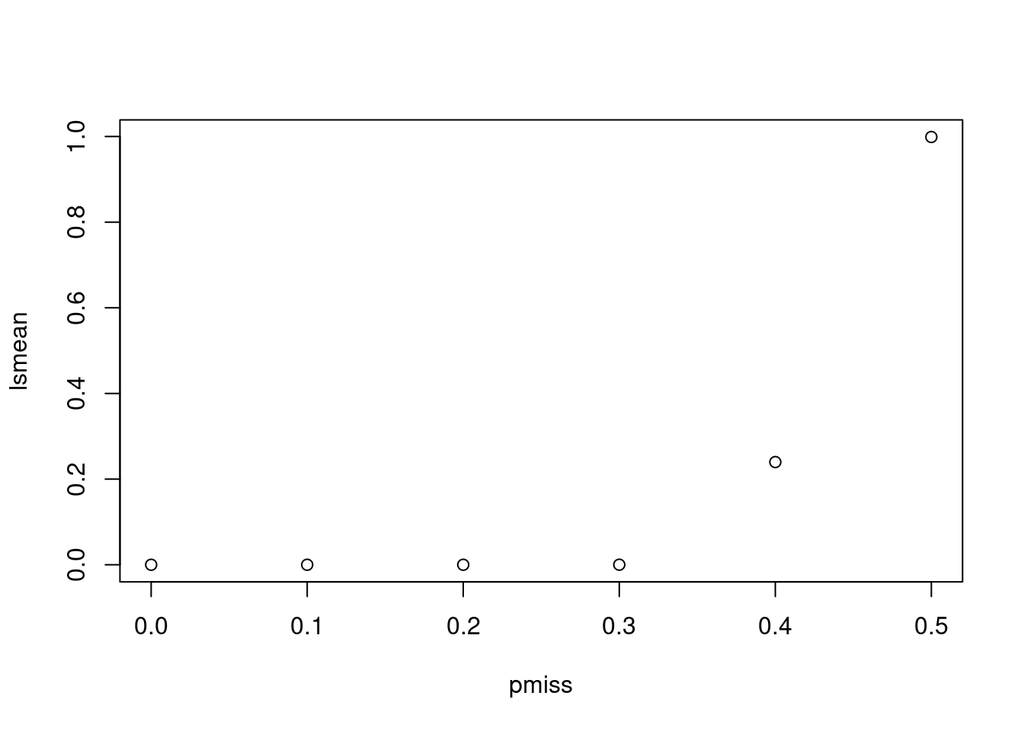

```r
plot(lsmean ~ pmiss,
     data = lsmeans(
       m.nulsim.randpmiss,
       "pmiss",
       type = "response",
       at = list(pmiss = c(0, .1, .2, .3, .4, .5))
     ))
```

Both of the obvious random effects models under-perform. The fixed effect terms are significant in the expected pattern, but the marginal means are way off. Possibly there is some odd effect stemming from the nature of exclusion as an event – i.e. if a participant is missing at .2mm of scrubbing, then they are also (always) missing at .1, and so on.

### Checking assumptions

Let’s do some assumption checks:

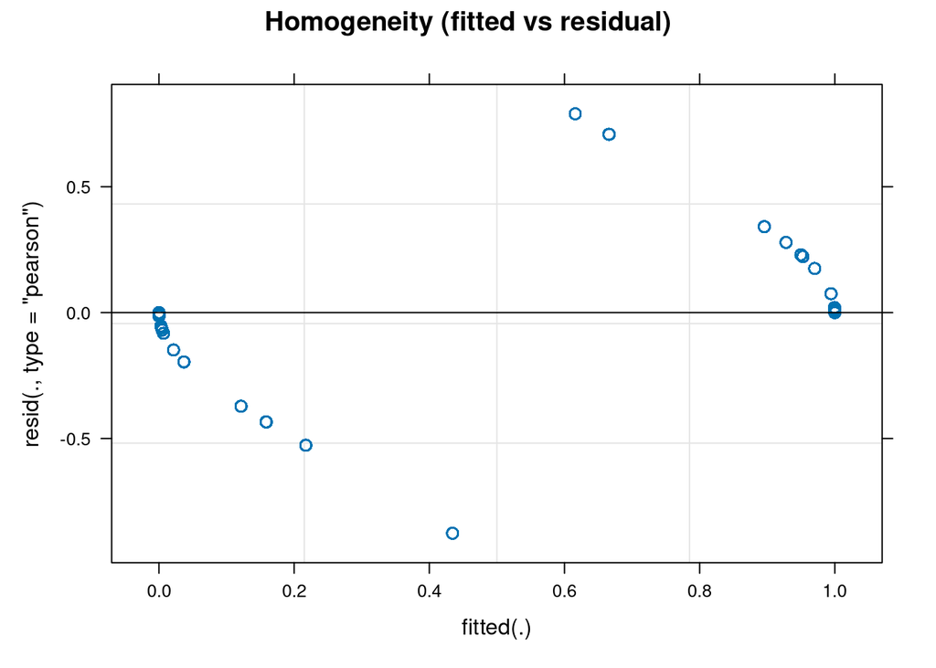

```r
# homogeneity
plot(m.nulsim.randpmiss,main="Homogeneity (fitted vs residual)")
```

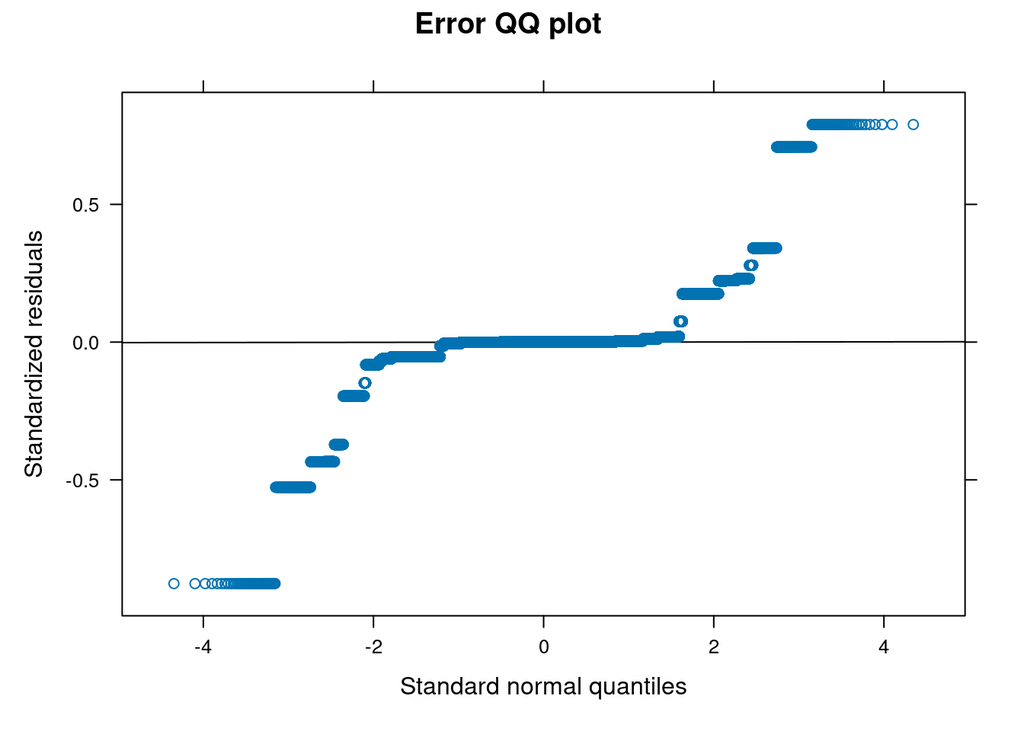

```r
# error normality
qqmath(m.nulsim.randpmiss,main="Error QQ plot ")
```

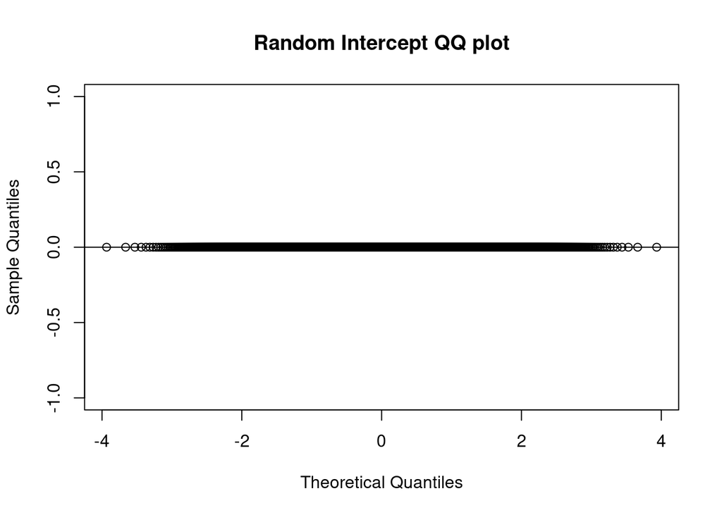

```r
# random effects normality
r_int<- ranef(m.nulsim.randpmiss)$sid$`(Intercept)`
qqnorm(r_int,main="Random Intercept QQ plot")
qqline(r_int)
```

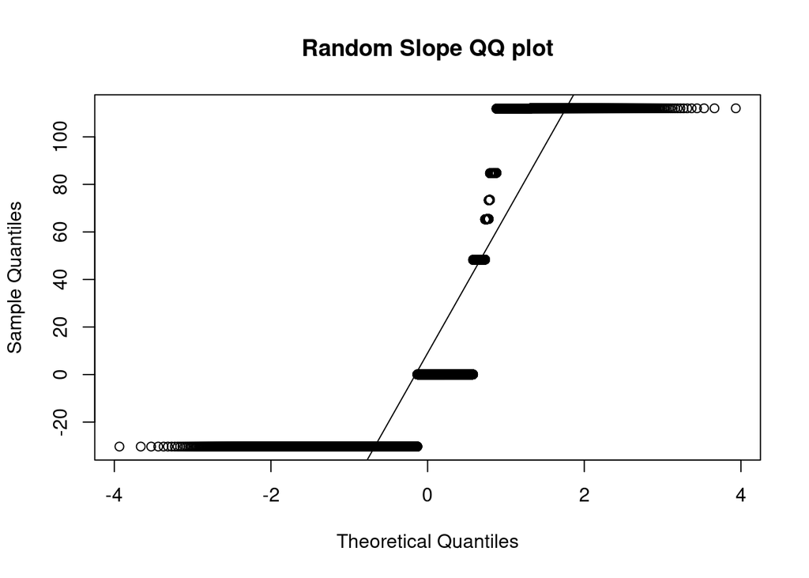

```r
r_slope<- ranef(m.nulsim.randpmiss)$sid$pmiss
qqnorm(r_slope,main="Random Slope QQ plot")
qqline(r_slope)
```

Not good on both counts.

## Linear mixed effect model.

What if we ditch the logistic function and just try to model probability?

```r
m.nulsim.randpmiss.linear <-
  lmer(ismiss ~ pmiss + sex + sex:pmiss + (pmiss | sid),
        data = nulsim.l)
summary(m.nulsim.randpmiss.linear)
```

```
## Linear mixed model fit by REML. t-tests use Satterthwaite's method [
## lmerModLmerTest]
## Formula: ismiss ~ pmiss + sex + sex:pmiss + (pmiss | sid)
##    Data: nulsim.l
##
## REML criterion at convergence: -10371.4
##
## Scaled residuals:
##     Min      1Q  Median      3Q     Max
## -5.4143 -0.0492  0.0111  0.1215  4.9354
##
## Random effects:
##  Groups   Name        Variance Std.Dev. Corr
##  sid      (Intercept) 0.30634  0.5535
##           pmiss       1.65026  1.2846   -0.74
##  Residual             0.01839  0.1356
## Number of obs: 72000, groups:  sid, 12000
##
## Fixed effects:
##               Estimate Std. Error         df t value Pr(>|t|)
## (Intercept)  1.217e-03  7.350e-03  1.200e+04   0.166    0.868
## pmiss        9.962e-01  1.753e-02  1.200e+04  56.844   <2e-16 ***
## sex1        -2.442e-03  1.041e-02  1.200e+04  -0.235    0.815
## pmiss:sex1   7.536e-03  2.482e-02  1.200e+04   0.304    0.761
## ---
## Signif. codes:  0 '***' 0.001 '**' 0.01 '*' 0.05 '.' 0.1 ' ' 1
##
## Correlation of Fixed Effects:
##            (Intr) pmiss  sex1
## pmiss      -0.747
## sex1       -0.706  0.527
## pmiss:sex1  0.527 -0.706 -0.747
```

```r
lsmeans(m.nulsim.randpmiss.linear,
        "pmiss",
        at = list(pmiss = c(0, .1, .2, .3, .4, .5)))
```

```
## Cannot use mode = "kenward-roger" because *pbkrtest* package is not installed
```

```
## Note: D.f. calculations have been disabled because the number of observations exceeds 3000.
## To enable adjustments, add the argument 'lmerTest.limit = 72000' (or larger)
## [or, globally, 'set emm_options(lmerTest.limit = 72000)' or larger];
## but be warned that this may result in large computation time and memory use.
```

```
## NOTE: Results may be misleading due to involvement in interactions
```

```
##  pmiss   lsmean      SE  df asymp.LCL asymp.UCL
##    0.0 -3.5e-06 0.00520 Inf   -0.0102    0.0102
##    0.1  1.0e-01 0.00436 Inf    0.0915    0.1085
##    0.2  2.0e-01 0.00373 Inf    0.1927    0.2073
##    0.3  3.0e-01 0.00346 Inf    0.2932    0.3068
##    0.4  4.0e-01 0.00362 Inf    0.3929    0.4071
##    0.5  5.0e-01 0.00416 Inf    0.4918    0.5082
##
## Results are averaged over the levels of: sex
## Degrees-of-freedom method: asymptotic
## Confidence level used: 0.95
```

[output not shown]

[output not shown]

```
## NOTE: Results may be misleading due to involvement in interactions
```

[output not shown]

[output not shown]

```
## NOTE: Results may be misleading due to involvement in interactions
```

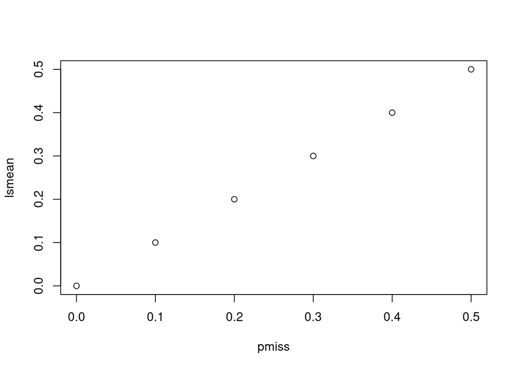

```r
plot(lsmean ~ pmiss,
     data = lsmeans(
       m.nulsim.randpmiss.linear,
       "pmiss",
       at = list(pmiss = c(0, .1, .2, .3, .4, .5))
     ))
```

```r
m.nulsim.randpmiss.noint.linear <-
  lmer(ismiss ~ pmiss + sex + sex:pmiss + 0 + (0 + pmiss | sid),
        data = nulsim.l)
summary(m.nulsim.randpmiss.noint.linear)
```

```
## Linear mixed model fit by REML. t-tests use Satterthwaite's method [
## lmerModLmerTest]
## Formula: ismiss ~ pmiss + sex + sex:pmiss + 0 + (0 + pmiss | sid)
##    Data: nulsim.l
##
## REML criterion at convergence: 48000.9
##
## Scaled residuals:
##      Min       1Q   Median       3Q      Max
## -1.87381 -0.74086 -0.08822 -0.07149  2.14358
##
## Random effects:
##  Groups   Name  Variance Std.Dev.
##  sid      pmiss 1.14211  1.0687
##  Residual       0.07874  0.2806
## Number of obs: 72000, groups:  sid, 12000
##
## Fixed effects:
##              Estimate Std. Error         df t value Pr(>|t|)
## pmiss       9.962e-01  1.818e-02  2.726e+04  54.790   <2e-16 ***
## sex0        1.217e-03  3.645e-03  6.000e+04   0.334    0.738
## sex1       -1.224e-03  3.655e-03  6.000e+04  -0.335    0.738
## pmiss:sex1  7.536e-03  2.575e-02  2.726e+04   0.293    0.770
## ---
## Signif. codes:  0 '***' 0.001 '**' 0.01 '*' 0.05 '.' 0.1 ' ' 1
##
## Correlation of Fixed Effects:
##            pmiss  sex0   sex1
## sex0       -0.597
## sex1        0.000  0.000
## pmiss:sex1 -0.706  0.421 -0.422
```

```r
lsmeans(m.nulsim.randpmiss.noint.linear,
        "pmiss",
        at = list(pmiss = c(0, .1, .2, .3, .4, .5)))
```

```
## Cannot use mode = "kenward-roger" because *pbkrtest* package is not installed
```

```
## Note: D.f. calculations have been disabled because the number of observations exceeds 3000.
## To enable adjustments, add the argument 'lmerTest.limit = 72000' (or larger)
## [or, globally, 'set emm_options(lmerTest.limit = 72000)' or larger];
## but be warned that this may result in large computation time and memory use.
```

```
## NOTE: Results may be misleading due to involvement in interactions
```

```
##  pmiss   lsmean      SE  df asymp.LCL asymp.UCL
##    0.0 -3.5e-06 0.00258 Inf  -0.00506   0.00505
##    0.1  1.0e-01 0.00209 Inf   0.09591   0.10409
##    0.2  2.0e-01 0.00232 Inf   0.19546   0.20454
##    0.3  3.0e-01 0.00311 Inf   0.29390   0.30610
##    0.4  4.0e-01 0.00416 Inf   0.39184   0.40816
##    0.5  5.0e-01 0.00532 Inf   0.48958   0.51042
##
## Results are averaged over the levels of: sex
## Degrees-of-freedom method: asymptotic
## Confidence level used: 0.95
```

[output not shown]

[output not shown]

```
## NOTE: Results may be misleading due to involvement in interactions
```

[output not shown]

[output not shown]

```
## NOTE: Results may be misleading due to involvement in interactions
```

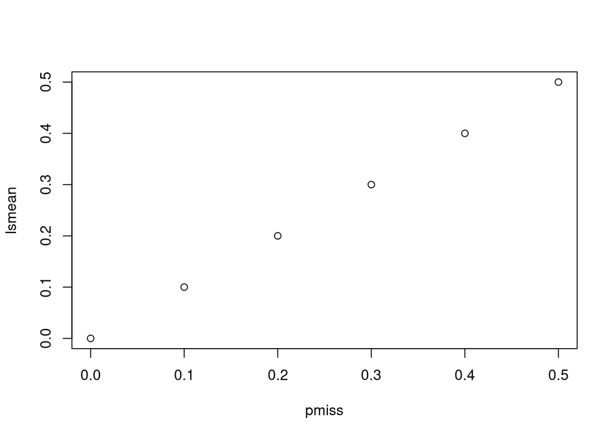

```r
plot(lsmean ~ pmiss,
     data = lsmeans(
       m.nulsim.randpmiss.noint.linear,
       "pmiss",
       at = list(pmiss = c(0, .1, .2, .3, .4, .5))
     ))
```

Both of these models work pretty well.

## Summing up

So far, it looks like we can do logistic regression OR have random effects. The random effect, linear, model appears to be a little more accurate. It may be that the logistic mixed-effect model is not working because pmiss increases linearly with probability, not logit probability. Let’s plot the marginal means in greater detail for our two logistic regression models:

```r
m.nulsim.fixed
```

```
##
## Call:  glm(formula = ismiss ~ pmiss + sex * pmiss, family = "binomial",
##     data = nulsim.l)
##
## Coefficients:
## (Intercept)        pmiss         sex1   pmiss:sex1
##    -2.24349      4.45632     -0.01231      0.03521
##
## Degrees of Freedom: 71999 Total (i.e. Null);  71996 Residual
## Null Deviance:       85500
## Residual Deviance: 80420     AIC: 80430
```

```r
mm1<-lsmeans(
       m.nulsim.fixed,
       "pmiss",
       type = "response",
       at = list(pmiss = seq(0,1,.05))
     )
```

```
## NOTE: Results may be misleading due to involvement in interactions
```

```r
mm2<-lsmeans(
       m.nulsim.randpmiss,
       "pmiss",
       type = "response",
       at = list(pmiss = seq(0,1,.05))
     )
```

```
## NOTE: Results may be misleading due to involvement in interactions
```

```r
mm3<-lsmeans(
       m.nulsim.randpmiss.linear,
       "pmiss",
       at = list(pmiss = seq(0,1,.05))
     )
```

```
## Cannot use mode = "kenward-roger" because *pbkrtest* package is not installed
```

```
## Note: D.f. calculations have been disabled because the number of observations exceeds 3000.
## To enable adjustments, add the argument 'lmerTest.limit = 72000' (or larger)
## [or, globally, 'set emm_options(lmerTest.limit = 72000)' or larger];
## but be warned that this may result in large computation time and memory use.
```

```
## NOTE: Results may be misleading due to involvement in interactions
```

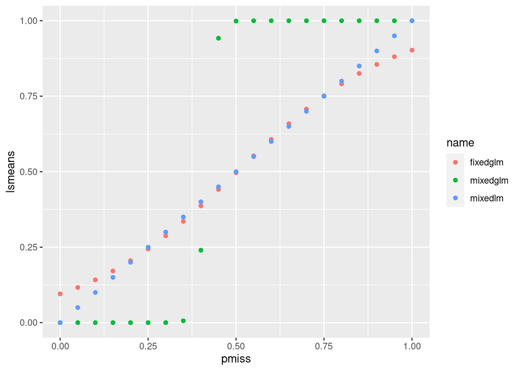

```r
data.frame(
  pmiss = summary(mm1)$pmiss,
  fixedglm = summary(mm1)$lsmean,
  mixedglm = summary(mm2)$lsmean,
  mixedlm = summary(mm3)$lsmean
) %>% pivot_longer(-pmiss, values_to = "lsmeans") %>%
  ggplot(aes(x = pmiss, y = lsmeans, color = name)) +
  geom_point()
```

So, the relation between pmiss and probability of exclusion is exactly linear. This probably make it hard to fit a logit, but it sort of works before we add random effects (the model diagnostic plots are still not good). What if we transform pmiss first?

```r
nulsim.l$pmisslogit<-qlogis(nulsim.l$pmiss)

m.nulsim.randpmisslogit <-
  glmer(ismiss ~ pmiss + sex + sex:pmisslogit + (pmisslogit |
                                              sid),
        data = nulsim.l,
        family = "binomial")
summary(m.nulsim.randpmisslogit)
```

```
## Generalized linear mixed model fit by maximum likelihood (Laplace
##   Approximation) [glmerMod]
##  Family: binomial  ( logit )
## Formula: ismiss ~ pmiss + sex + sex:pmisslogit + (pmisslogit | sid)
##    Data: nulsim.l
##
##      AIC      BIC   logLik deviance df.resid
##  35162.5  35236.0 -17573.3  35146.5    71992
##
## Scaled residuals:
##      Min       1Q   Median       3Q      Max
## -1.00854 -0.00712 -0.00030  0.02833  0.99366
##
## Random effects:
##  Groups Name        Variance Std.Dev. Corr
##  sid    (Intercept)  5.316   2.306
##         pmisslogit  60.937   7.806    -1.00
## Number of obs: 72000, groups:  sid, 12000
##
## Fixed effects:
##                   Estimate Std. Error  z value Pr(>|z|)
## (Intercept)      1.213e+02  5.152e-05  2354560   <2e-16 ***
## pmiss           -2.433e+02  5.152e-05 -4722525   <2e-16 ***
## sex1             1.013e-01  5.152e-05     1965   <2e-16 ***
## sex0:pmisslogit  6.339e+01  5.152e-05  1230325   <2e-16 ***
## sex1:pmisslogit  6.295e+01  5.152e-05  1221715   <2e-16 ***
## ---
## Signif. codes:  0 '***' 0.001 '**' 0.01 '*' 0.05 '.' 0.1 ' ' 1
##
## Correlation of Fixed Effects:
##             (Intr) pmiss sex1  sx0:pm
## pmiss       0.000
## sex1        0.000  0.000
## sx0:pmsslgt 0.000  0.000 0.000
## sx1:pmsslgt 0.000  0.000 0.000 0.000
## optimizer (Nelder_Mead) convergence code: 0 (OK)
## Model failed to converge with max|grad| = 1.38658 (tol = 0.002, component 1)
## Model is nearly unidentifiable: very large eigenvalue
##  - Rescale variables?
```

```r
lsmeans(m.nulsim.randpmisslogit,
        "pmisslogit",
        type = "response",
        at = list(pmisslogit = qlogis(c(.10, .20, .30, .40, .50))))
```

```
## NOTE: A nesting structure was detected in the fitted model:
##     pmisslogit %in% sex
```

```
##  pmisslogit sex  lsmean         SE  df asymp.LCL asymp.UCL
##    -2.19722 0   0.00000 0.0000e+00 Inf   0.00000   0.00000
##    -1.38629 0   0.00000 0.0000e+00 Inf   0.00000   0.00000
##    -0.84730 0   0.32602 1.5175e-05 Inf   0.32599   0.32605
##    -0.40547 0   1.00000 0.0000e+00 Inf   1.00000   1.00000
##     0.00000 0   1.00000 0.0000e+00 Inf   1.00000   1.00000
##    -2.19722 1   0.00000 0.0000e+00 Inf   0.00000   0.00000
##    -1.38629 1   0.00000 0.0000e+00 Inf   0.00000   0.00000
##    -0.84730 1   0.43816 2.1212e-05 Inf   0.43812   0.43820
##    -0.40547 1   1.00000 0.0000e+00 Inf   1.00000   1.00000
##     0.00000 1   1.00000 0.0000e+00 Inf   1.00000   1.00000
##
## Confidence level used: 0.95
## Intervals are back-transformed from the logit scale
```

No that doesn’t help.

# Modeling H1

Now we’ll use data with a bias. Let’s compare a ‘full’ model, one with no intercept, and one with no intercept and no main effect of sex.

```r
h1probepoints=list(pmiss=c(.1,.2,.3,.4,.5,.6),
                   sex=unique(h1sim.l$sex))

m.h1.full <-
  lmer(ismiss ~ pmiss + sex + sex:pmiss + (pmiss | sid),
        data = h1sim.l)
summary(m.h1.full)
```

```
## Linear mixed model fit by REML. t-tests use Satterthwaite's method [
## lmerModLmerTest]
## Formula: ismiss ~ pmiss + sex + sex:pmiss + (pmiss | sid)
##    Data: h1sim.l
##
## REML criterion at convergence: 27136.5
##
## Scaled residuals:
##      Min       1Q   Median       3Q      Max
## -1.92995 -0.34210 -0.06189  0.18613  2.69426
##
## Random effects:
##  Groups   Name        Variance Std.Dev. Corr
##  sid      (Intercept) 0.009012 0.09493
##           pmiss       0.714852 0.84549  0.53
##  Residual             0.055161 0.23486
## Number of obs: 72000, groups:  sid, 12000
##
## Fixed effects:
##               Estimate Std. Error         df t value Pr(>|t|)
## (Intercept) -1.985e-03  2.485e-03  1.200e+04  -0.799    0.425
## pmiss        8.264e-01  1.291e-02  1.200e+04  64.005   <2e-16 ***
## sex1         3.981e-03  3.520e-03  1.200e+04   1.131    0.258
## pmiss:sex1   3.481e-01  1.829e-02  1.200e+04  19.037   <2e-16 ***
## ---
## Signif. codes:  0 '***' 0.001 '**' 0.01 '*' 0.05 '.' 0.1 ' ' 1
##
## Correlation of Fixed Effects:
##            (Intr) pmiss  sex1
## pmiss      -0.164
## sex1       -0.706  0.116
## pmiss:sex1  0.116 -0.706 -0.164
```

```r
rsq(m.h1.full)
```

```
## $model
## [1] 0.7324469
##
## $fixed
## [1] 0.1837019
##
## $random
## [1] 0.548745
```

```r
lsmeans.h1.full<-lsmeans(m.h1.full,
        ~sex|pmiss,
        "pmiss",
        at = h1probepoints)
```

```
## Cannot use mode = "kenward-roger" because *pbkrtest* package is not installed
```

```
## Note: D.f. calculations have been disabled because the number of observations exceeds 3000.
## To enable adjustments, add the argument 'lmerTest.limit = 72000' (or larger)
## [or, globally, 'set emm_options(lmerTest.limit = 72000)' or larger];
## but be warned that this may result in large computation time and memory use.
```

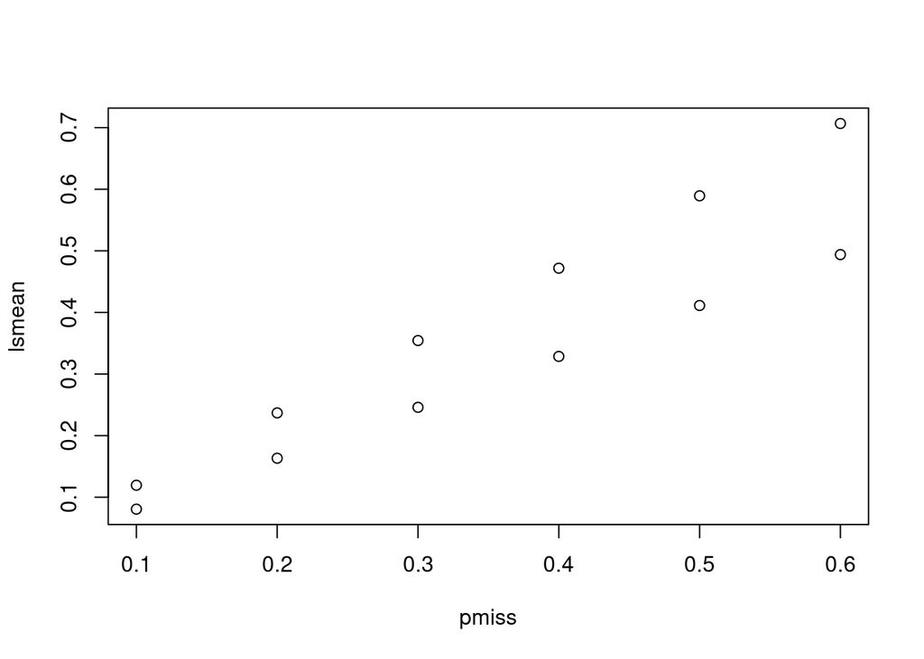

```r
plot(lsmean ~ pmiss,
     data = lsmeans.h1.full
     )
```

```r
m.h1.noint<-lmer(ismiss ~ pmiss + sex + sex:pmiss + 0 + (0 + pmiss | sid),
        data = h1sim.l)
summary(m.h1.full)
```

```
## Linear mixed model fit by REML. t-tests use Satterthwaite's method [
## lmerModLmerTest]
## Formula: ismiss ~ pmiss + sex + sex:pmiss + (pmiss | sid)
##    Data: h1sim.l
##
## REML criterion at convergence: 27136.5
##
## Scaled residuals:
##      Min       1Q   Median       3Q      Max
## -1.92995 -0.34210 -0.06189  0.18613  2.69426
##
## Random effects:
##  Groups   Name        Variance Std.Dev. Corr
##  sid      (Intercept) 0.009012 0.09493
##           pmiss       0.714852 0.84549  0.53
##  Residual             0.055161 0.23486
## Number of obs: 72000, groups:  sid, 12000
##
## Fixed effects:
##               Estimate Std. Error         df t value Pr(>|t|)
## (Intercept) -1.985e-03  2.485e-03  1.200e+04  -0.799    0.425
## pmiss        8.264e-01  1.291e-02  1.200e+04  64.005   <2e-16 ***
## sex1         3.981e-03  3.520e-03  1.200e+04   1.131    0.258
## pmiss:sex1   3.481e-01  1.829e-02  1.200e+04  19.037   <2e-16 ***
## ---
## Signif. codes:  0 '***' 0.001 '**' 0.01 '*' 0.05 '.' 0.1 ' ' 1
##
## Correlation of Fixed Effects:
##            (Intr) pmiss  sex1
## pmiss      -0.164
## sex1       -0.706  0.116
## pmiss:sex1  0.116 -0.706 -0.164
```

```r
lsmeans(m.h1.full,
        "pmiss",
        at = h1probepoints)
```

```
## Cannot use mode = "kenward-roger" because *pbkrtest* package is not installed
## Note: D.f. calculations have been disabled because the number of observations exceeds 3000.
## To enable adjustments, add the argument 'lmerTest.limit = 72000' (or larger)
## [or, globally, 'set emm_options(lmerTest.limit = 72000)' or larger];
## but be warned that this may result in large computation time and memory use.
```

```
## NOTE: Results may be misleading due to involvement in interactions
```

```
##  pmiss lsmean      SE  df asymp.LCL asymp.UCL
##    0.1    0.1 0.00185 Inf    0.0964     0.104
##    0.2    0.2 0.00232 Inf    0.1956     0.205
##    0.3    0.3 0.00301 Inf    0.2943     0.306
##    0.4    0.4 0.00379 Inf    0.3928     0.408
##    0.5    0.5 0.00462 Inf    0.4912     0.509
##    0.6    0.6 0.00548 Inf    0.5896     0.611
##
## Results are averaged over the levels of: sex
## Degrees-of-freedom method: asymptotic
## Confidence level used: 0.95
```

```r
plot(lsmean ~ pmiss,
     data = lsmeans(
       m.nulsim.randpmiss.noint.linear,
       "pmiss",
       at = h1probepoints)
     )
```

[output not shown]

[output not shown]

[output not shown]

```
## NOTE: Results may be misleading due to involvement in interactions
```

[output not shown]

[output not shown]

```
## NOTE: Results may be misleading due to involvement in interactions
```

```r
m.h1.nointnomain<-lmer(ismiss ~ pmiss + sex:pmiss + 0 + (0 + pmiss | sid),
        data = h1sim.l)
```

```
## fixed-effect model matrix is rank deficient so dropping 1 column / coefficient
```

```r
summary(m.h1.full)
```

```
## Linear mixed model fit by REML. t-tests use Satterthwaite's method [
## lmerModLmerTest]
## Formula: ismiss ~ pmiss + sex + sex:pmiss + (pmiss | sid)
##    Data: h1sim.l
##
## REML criterion at convergence: 27136.5
##
## Scaled residuals:
##      Min       1Q   Median       3Q      Max
## -1.92995 -0.34210 -0.06189  0.18613  2.69426
##
## Random effects:
##  Groups   Name        Variance Std.Dev. Corr
##  sid      (Intercept) 0.009012 0.09493
##           pmiss       0.714852 0.84549  0.53
##  Residual             0.055161 0.23486
## Number of obs: 72000, groups:  sid, 12000
##
## Fixed effects:
##               Estimate Std. Error         df t value Pr(>|t|)
## (Intercept) -1.985e-03  2.485e-03  1.200e+04  -0.799    0.425
## pmiss        8.264e-01  1.291e-02  1.200e+04  64.005   <2e-16 ***
## sex1         3.981e-03  3.520e-03  1.200e+04   1.131    0.258
## pmiss:sex1   3.481e-01  1.829e-02  1.200e+04  19.037   <2e-16 ***
## ---
## Signif. codes:  0 '***' 0.001 '**' 0.01 '*' 0.05 '.' 0.1 ' ' 1
##
## Correlation of Fixed Effects:
##            (Intr) pmiss  sex1
## pmiss      -0.164
## sex1       -0.706  0.116
## pmiss:sex1  0.116 -0.706 -0.164
```

```r
lsmeans(m.h1.full,
        "pmiss",
        at = h1probepoints)
```

```
## Cannot use mode = "kenward-roger" because *pbkrtest* package is not installed
```

```
## Note: D.f. calculations have been disabled because the number of observations exceeds 3000.
## To enable adjustments, add the argument 'lmerTest.limit = 72000' (or larger)
## [or, globally, 'set emm_options(lmerTest.limit = 72000)' or larger];
## but be warned that this may result in large computation time and memory use.
```

```
## NOTE: Results may be misleading due to involvement in interactions
```

```
##  pmiss lsmean      SE  df asymp.LCL asymp.UCL
##    0.1    0.1 0.00185 Inf    0.0964     0.104
##    0.2    0.2 0.00232 Inf    0.1956     0.205
##    0.3    0.3 0.00301 Inf    0.2943     0.306
##    0.4    0.4 0.00379 Inf    0.3928     0.408
##    0.5    0.5 0.00462 Inf    0.4912     0.509
##    0.6    0.6 0.00548 Inf    0.5896     0.611
##
## Results are averaged over the levels of: sex
## Degrees-of-freedom method: asymptotic
## Confidence level used: 0.95
```

[output not shown]

[output not shown]

```
## NOTE: Results may be misleading due to involvement in interactions
```

[output not shown]

[output not shown]

```
## NOTE: Results may be misleading due to involvement in interactions
```

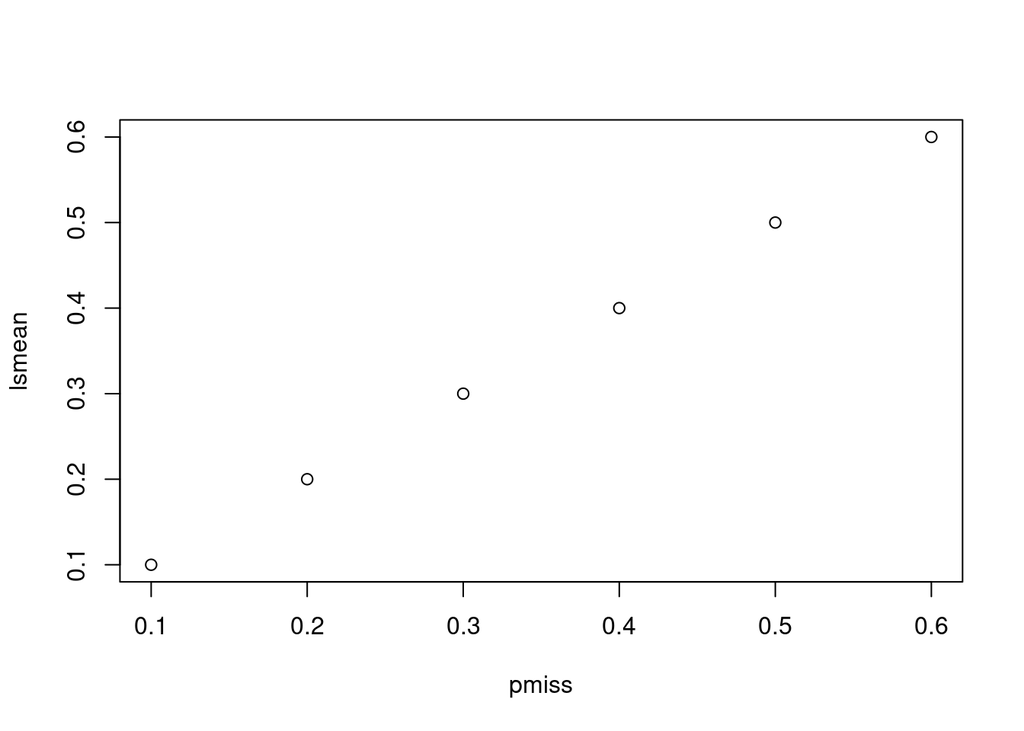

```r
plot(lsmean ~ pmiss,
     data = lsmeans(
       m.nulsim.randpmiss.noint.linear,
       "pmiss",
       at = h1probepoints)
     )
```

The full model shows no main effect of sex, but does show an interaction. This invalidates our analysis plan for H2, as we expected an interaction would indicate increasing bias by condition (but here we see one where the bias is constant as data is excluded). Instead, we will need to test for a quadratic interaction.